# Práctico Haskell 1: Tipos de Datos, Clases de Tipos

# Tipos Algebraicos de Datos

Definir los tipos y funciones siguientes en un archivo `tipos.hs`.

## 1. Tipos enumerados

[figure not shown]

Cuando los distintos valores que debemos distinguir en un tipo son finitos, podemos enumerar todos los valores distintos para el tipo. Por ejemplo, podrı́amos representar los tı́tulos nobiliarios de algún paı́s (retrógrado) con el siguiente tipo:

```haskell
data Titulo = Ducado | Marquesado | Condado | Vizcondado | Baronia
```

1. Definí el tipo `Titulo` como descrito arriba. No tiene que pertenecer a la clase `Eq`.
2. Definí `hombre :: Titulo -> String` que devuelve la forma masculina del tı́tulo.
3. Definí la función `dama` que devuelve la inflexión femenina.

## 2. Constructores con parámetros

[figure not shown]

En este ejercicio, introducimos dos conceptos: los sinónimos de tipos y tipos algebraicos cuyos constructores llevan parámetros. Los sinónimos de tipos nos permiten definir nombres de tipos nuevo a partir de tipos ya existentes:

```haskell
-- Territorio y Nombre son sinonimos de tipo.
type Territorio = String
type Nombre = String

cba , bsas :: Territorio
cba = "Cordoba"
bsas = "Buenos Aires"

alicia , bob :: Nombre
alicia = "Alicia"
bob = "Bob"
```

Los tipos algebraicos tienen constructores que llevan parámetros. Esos parámetros nos permiten agregar información; por ejemplo, en este ejercicio además de distinguir el rango de cada persona, representamos datos pertinentes a cada tipo de persona:

```haskell
-- Persona es un tipo algebraico
data Persona = Rey                  -- constructor sin parametro
          | Noble Titulo Territorio -- constructor con dos parametros
          | Caballero Nombre        -- constructor con un parametro
          | Aldeano Nombre          -- constructor con un parametro
```

1. Definí los tipos `Territorio`, `Nombre` y `Persona` como descrito arriba. Este último tipo *no debe pertenecer a la clase `Eq`*.
2. Definí la función `tratamiento :: Persona -> String` que dada una persona devuelve la forma en que se lo menciona en la corte. Esto es, al rey se lo nombra "Su majestad el rey", a un noble se lo nombra "El de ", a un caballero "Sir " y a un aldeano simplemente con su nombre.
3. Agreguemos el tipo `data Genero = Hombre | Mujer` a nuestro módulo. ¿Cómo modificar el tipo `Persona` para poder representar personas de distintos géneros *sin agregarle más constructores*? Realizá esta modificación y vuelva a programar la función `tratamiento` de forma tal de respetar el género de la persona al nombrarla.
4. Definí la función `sirs :: [Persona] -> [String]` que dada un lista de personas devuelve solo los nombres de los hombres. Definila con dos casos: el caso base y el inductivo.
5. Definí una versión alternativa de esta última función, `sirs'`, con un solo caso, usando la función `filter`.

## 3. El tipo polimórfico `Maybe`

`Maybe` es un tipo predefinido en Haskell cuya definición es la siguiente:

```haskell
data Maybe a = Nothing | Just a
```

El tipo `Maybe` sirve para "envolver" un tipo existente (el tipo `a`) y darle un valor extra (`Nothing`) que representa la ausencia de valor, o alguna falla.

El tipo `Maybe` es *polimórfico* porque en situaciones concretas, puede tomar como parámetro otro tipo: `Maybe Int`, `Maybe String`, etc.

Definí las funciones siguientes:

1. `division_segura :: Int -> Int -> Maybe Int`, que toma dos enteros y devuelve `Nothing` si el segundo es cero, o `Just c` donde `c` es el cociente del primero por el segundo.
2. `cabeza :: [a] -> Maybe a` que toma una lista y devuelve el primer elemento (dentro de `Just`) solamente si la lista no es vacía, y `Nothing` si es vacía.
3. `suma_maybe :: Maybe Int -> Maybe Int -> Maybe Int` que toma dos "enteros Maybe", y solo devuelve un `Just` de la suma si los dos son `Just`. En los otros casos, devuelve `Nothing`.
4. `suma_maybe_num :: Num a => Maybe a -> Maybe a -> Maybe a`, una versión más general de `suma_maybe`.

## 4. Tipos recursivos y polimórficos

Consideremos la siguiente definición de tipo de datos:

```haskell
data ListAssoc a b = Empty
                   | Node a b (ListAssoc a b)
```

Este tipo es *recursivo* porque él mismo (`ListAssoc a b`) aparece como un argumento de uno de sus constructores (`Node`). Los parámetross del constructor de tipo (`ListAssoc`) indican que es un tipo polimórfico, donde las variables `a` y `b` se pueden instanciar con distintos tipos; por ejemplo:

```haskell
type Diccionario = ListAssoc String String
type DNI = Int
type Padron      = ListAssoc DNI    String
```

Definí las siguientes funciones:

1. `la_comodin :: Int -> ListAssoc Int Int` que, dada un entero positivo `n`, construye un lista asociativa de `n` entradas desde `n` hasta `1`, cada entrada teniendo asociado el valor 0. Por ejemplo:

   ```haskell
   la_comodin 1 == Node 1 0 Empty
   la_comodin 3 == Node 3 0 (Node 2 0 (Node 1 0 Empty))
   la_comodin 0 == Empty
   ```

   Como `ListAssoc` no pertenece a la clase `Show`, no vas a poder comprobar esta función sola en GHCi, recién en conjunto con las funciones siguientes vas a poder ver si anda bien.
2. `la_long :: ListAssoc a b -> Int` que devuelve la cantidad de datos en una lista.
3. `la_pares :: ListAssoc a b -> [(a,b)]` que devuelve la lista de pares contenida en la lista de asociaciones.
4. `la_existe :: Eq a => ListAssoc a b -> a -> Bool` que dada una lista y una clave devuelve `True` si la clave está y `False` en caso contrario.
5. `la_buscar :: Eq a => ListAssoc a b -> a -> Maybe b` que dada una lista y una clave devuelve el dato asociado si es que existe. Podés consultar la definición del tipo `Maybe` en Hoogle.
6. `la_agregar :: Eq a => a -> b -> ListAssoc a b -> ListAssoc a b` que dada una clave `a`, un dato `b` lo agrega en la lista si la clave a NO existe. En caso de que la clave `a` exista, se aplasta el dato anterior.
7. `la_borrar :: Eq a => a ListAssoc a b -> ListAssoc a b` que dada una clave `a` elimina la entrada en la lista.

# Polinomios

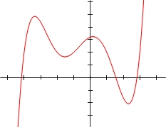

## Preparación

Bajá el archivo pre-llenado: Poly.hs.

## ¿Qué es un número?

Parece una pregunta profunda y filosófica, pero el sistema de tipos de Haskell nos da una respuesta simple: un número es cualquier tipo que tiene una instancia de la clase de tipos `Num`. Veamos la definición de `Num`:

```haskell
class Num a where
    (+), (-), (*)  :: a -> a -> a
    negate         :: a -> a
    abs            :: a -> a
    signum         :: a -> a
    fromInteger    :: Integer -> a
```

Entonces, para Haskell, un número es simplemente algo que puede ser sumado, restado, multiplicado, negado, etc. (La división no es parte de la clase `Num` a propósito, dado que es definida de manera distinta para los enteros y los flotantes.) El Prelude de Haskell viene con varias instancias de `Num` que ya conocemos. Incluyen los sospechosos de siempre: `Int`, `Integer`, `Float` y `Double`. Pero la diversión no termina acá. Podemos definir nuestros propios números, del momento que podemos proveer definiciones sensatas para las operaciones numéricas básicas.

## ¿Un polinomio puede ser un número?

¡Cómo no! Los polinomios pueden sumarse, restarse y multiplicarse como cualquier otro número. En estos ejercicios, vamos a escribir una instancia de `Num` para un tipo de polinomios que definimos nosotros.

Pensemos en como definir ese tipo. Un polinomio es simplemente una secuencia de términos, y cada término tiene un coeficiente y un grado. Por ejemplo, el polinomio *x*<sup>2</sup> + 5*x* + 3 tiene tres términos, uno de grado 2 con coeficiente 1, uno de grado 1 con coeficiente 5, y uno de grado 0 con coeficiente 3.

Vamos a evitar de especificar explicitamente los grados, y vamos a representar un polinomio como una lista de coeficientes, cada uno teniendo un grado igual a su posición en la lista. Vamos a permitir que el tipo de los coeficientes sea polimórfico, así podemos tener coeficientes que sean de tipo `Int`, `Double`, etc.

```haskell
data Poly a = P [a]
```

En esta representación, el polinomio *x*<sup>2</sup> + 5*x* + 3 se escribe `P [3, 5, 1]`.

## Ejercicio 1

Observamos que nuestro tipo `Poly a` no deriva las clases `Eq` y `Show`. ¡Hay una excelente razón para eso! Las instancias por defecto de esas clases de tipo no funcionarían tal como quisieramos.

En este ejercicio, vamos a escribir una instancia de la clase `Eq` para el `Poly a`. Si hubieramos derivado esa instancia, Haskell simplemente compararía las listas dentro del constructor `P`. Pensemos en porqué esto no alcanza. ¿Cuándo es el caso que dos `Poly` son equivalentes, pero sus representaciones en lista no lo son?

Implementá la función `(==)`. Acordate que no es necesario implementar explicitamente la función `(/=)`; tiene una implementation por defecto en términos de `(==)`. Ejemplos:

```haskell
P [1, 2, 3] == P [1, 2, 3]
P [1, 2] /= P [1, 2, 3]
```

Algunas funciones útiles pueden ser `takeWhile`, `dropWhile`, `reverse` ...

## Ejercicio 2

La instancia por defecto de `Show` muestra simplemente valores tal como están escritos en Haskell. Sería mucho mejor si un `Poly a` como `P [1, 2, 3]` pudiera ser mostrado de manera más legible por un humano, como `3x^2 + 2x + 1`.

Una instancia completa del tipo `Show` tendrá las características siguientes:

- los términos son mostrados como `cx^e` donde `c` es el coeficiente y `e` es el exponente. Si `e` es 0, entonces se muestra solo el coeficiente. Si `e` es 1, entonces el formato es simplemente `cx`.
- los términos son separados por el símbolo `+` con un solo espacio de cada lado
- los términos son listados en orden decreciente de grado
- los términos que tienen coeficiente 0 no se muestran, salvo si el polinomio es igual a 0
- ningún coeficiente se muestra para un término cuyo coeficiente es 1, (o sea `x` en lugar de `1x`), salvo si su grado es 0
- ningún tratamiento especial es necesario para los términos con coeficiente negativo. Por ejemplo, `2x^2 + -3` es la representación correcta de 2*x*<sup>2</sup> − 3.

Implementá la función `show` según esta especificación. Ejemplos:

```haskell
show (P [1, 0, 0, 2]) == "2x^3 + 1"
show (P [0, -1, 2]) == "2x^2 + -x"
```

Algunas funciones útiles pueden ser: `zip`, `reverse`, `intercalate` (del módulo `Data.List`)...

## Ejercicio 3

Ahora vamos a definir la suma para el tipo `Poly a`.

La suma para polinomios es bastante simple, todo lo que tenemos que hacer es sumar los pares de coeficientes para cada grado de los dos polinomios. Por ejemplo, (*x*<sup>2</sup> + 5)+(2*x*<sup>2</sup> + *x* + 1)=3*x*<sup>2</sup> + *x* + 6.

Se considera como buen estilo Haskell definir las funciones importantes fuera de la instancia de clase de tipo. Por esa razón, vamos a escribir la función `plus` que suma dos valores de tipo `Poly a`:

```haskell
plus :: Num a => Poly a -> Poly a -> Poly a
```

Observamos que el protótipo de `plus` indica la restricción que `a` tiene una instancia `Num`. Esto significa que solo podemos sumar polinomios que tienen coeficientes numéricos.

Como `a` tiene que ser un `Num`, podemos usar todas las funciones `Num` usuales (i.e., `(+)`) sobre los coeficientes de los polinomios. Ejemplos:

```haskell
P [5, 0, 1] + P [1, 1, 2] == P [6, 1, 3]
P [1, 0, 1] + P [1, 1] == P [2, 1, 1]
```

Definí la función `plus`.

## Ejercicio 4

En este ejercicio vamos a implementar la multiplicación de polinomios. Para multiplicar dos polinomios, cada término del primer polinomio debe ser multiplicado por cada término del segundo. La manera más simple de lograr esto es de construir un `[Poly a]` donde cada elemento es el polinomio que resulta de la multiplicación de un solo coeficiente en el primer polinomio por cada coeficiente en el segundo.

Dado que los términos no dicen explicitamente sus exponentes, vamos a tener que desplazar la salida antes de multiplicarla por cada coeficiente consecutivo. Por ejemplo, `P [1, 1, 1] * P [2, 2]` va a producir la lista `[P [2, 2], P [0, 2, 2], P [0, 0, 2, 2]]`.

Luego, podemos simplemente sumar esta lista. La función `sum` de Haskell es definida en términos de `(+)`, pero también utiliza el literal numérico `0`. Si queremos usar la función `sum` entonces tenemos que implementar la función `fromInteger` en la instancia de `Num` para `Poly a` primero (lo vamos a hacer en el próximo ejercicio de todos modos).

Sino, podemos también usar `foldr (+) (P [0])` en lugar de `sum` hasta que implementemos `fromInteger`

Implementá la función:

```haskell
times :: Num a => Poly a -> Poly a -> Poly a
```

Ejemplo:

```haskell
P [1, 1, 1] * P [2, 2] == P [2, 4, 4, 2]
```

## Ejercicio 5

Ya llegó la hora de completar nuestra definición de la instancia `Num` para los polinomios. Las funciones `(+)` y `(*)` ya fueron completadas en los ejercicios anteriores. Solo necesitamos implementar dos funciones más.

La primera función que vamos a implementar es `negate`. Esta función debe devolver la negación de un `Poly a`. En otros términos, el resultado de negar todos sus términos.

```haskell
negate :: Num a => Poly a -> Poly a
```

Ejemplo:

```haskell
negate (P [1, 2, 3]) == P [-1, -2, -3]
```

Definí `negate`.

De paso, la clase de tipo `Num` tiene una implementación por defecto de `(-)` en términos de `(+)` y `negate`, entonces no tenemos que implementarla.

Luego, implementá `fromInteger`. Esta función debe tomar un `Integer` y devolver un `Poly a`. Un entero (o cualquier número estándar) se puede ver como un polinomio de grado 0. Acordémonos que tenemos que convertir ese `Integer` a un valor de tipo `a` antes de poder usarlo como coeficiente en un polinomio.

```haskell
fromInteger :: Num a => Integer -> Poly a
```

La clase de tipo `Num` tiene dos funciones más que no tienen realmente sentido para los polinomios (capaz que los polinomios no son números, después de todo…). Esas funciones son `abs`y `signum`. Las vamos a dejar como `undefined` dado que el valor absoluto de un polinomio no es un polinomio, y los polinomios no tienen realmente un signo.

## Ejercicio 6

Ahora queremos poder escribir expresiones como `3x^2 + x^2 + 8`, y que sea interpretado como polinomio por Haskell, directamente.

Primero necesitamos hacer un truco para que `x` sea interpretado como esperamos. Considerá el protótipo siguiente:

```haskell
x :: Num a => Poly
```

Agregá la definición correspondiente para que `x` sea el polinomio *x*.

A esta altura, con todo lo que hiciste, el polinomio *x*<sup>2</sup> + 5*x* + 3 se puede escribir `x^2 + 5*x + 3` porque los valores `x`, `5` y `3` son todos valores válidos del tipo `Poly Int`, y definiste `(+)` y `(*)` como parte de la instancia `Num` para polinomios.

Podés ver que ahora se puede usar `(^)` para la exponenciación, por más que no lo hayas implementado. En Haskell, `(^)` es definido en términos de `(*)`, por lo cual viene "gratis".

Para terminar, definí la función `applyP` que aplica un `Poly a` a un valor de tipo `a`:

```haskell
applyP (x^2 + 2*x + 1) 1 == 4
applyP (x^2 + 2*x + 1) 2 == 9
```